# CS5801 Coursework Template Proforma

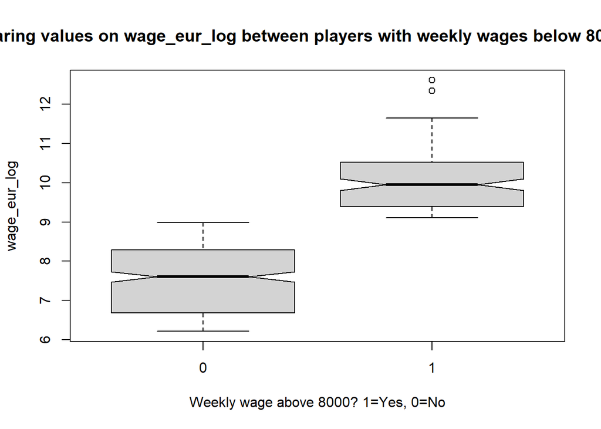

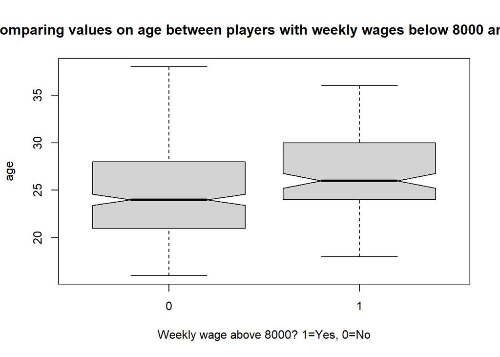

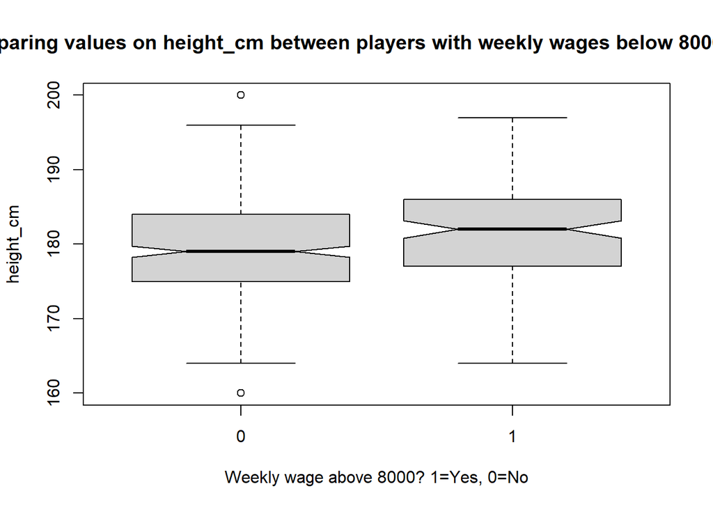

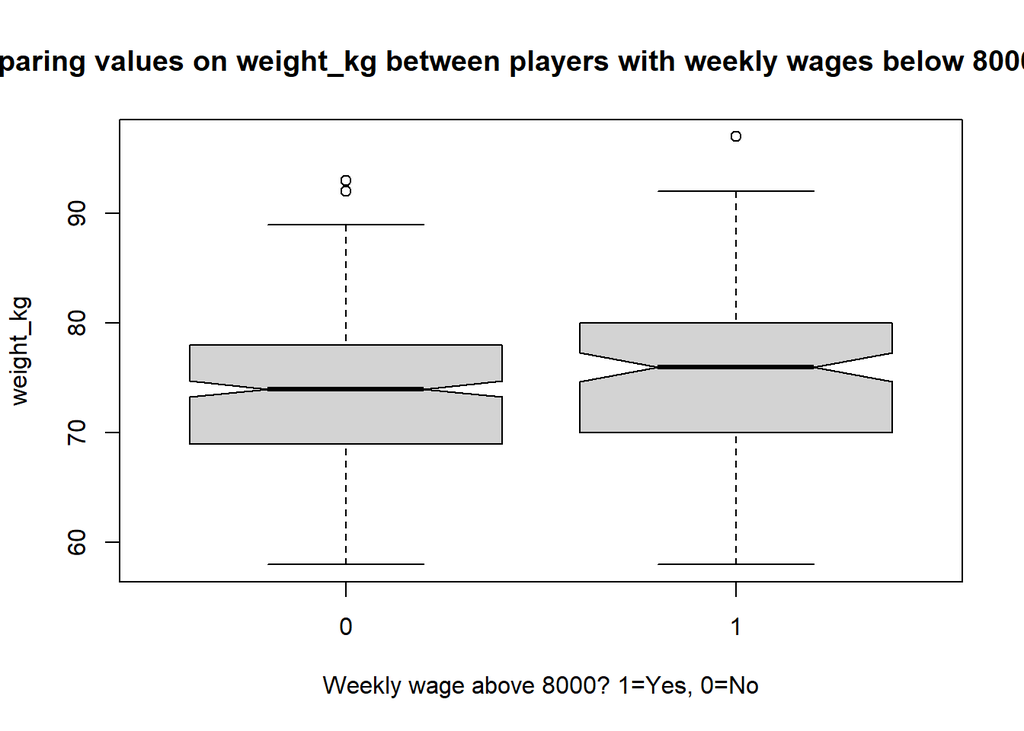

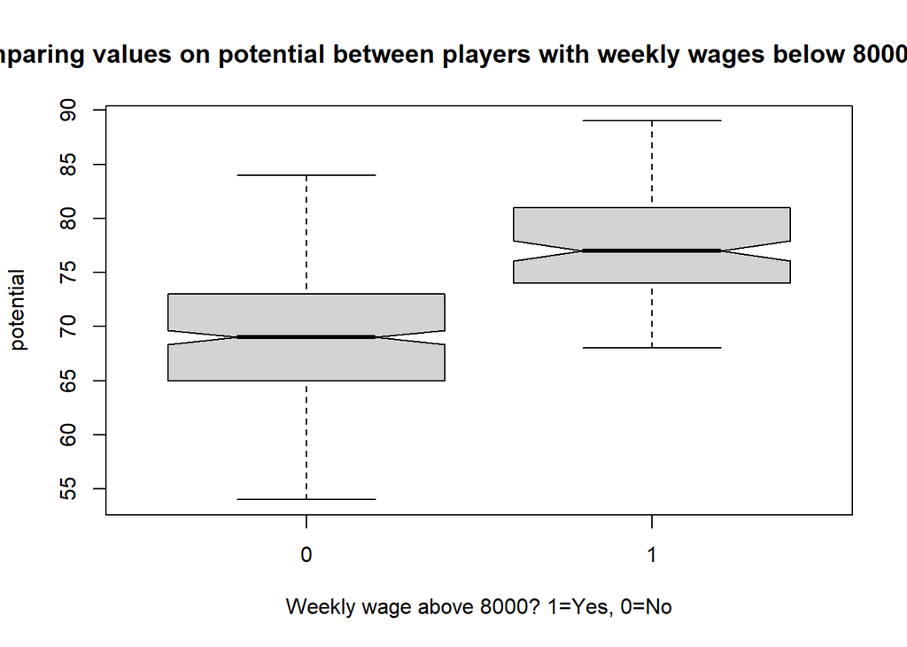

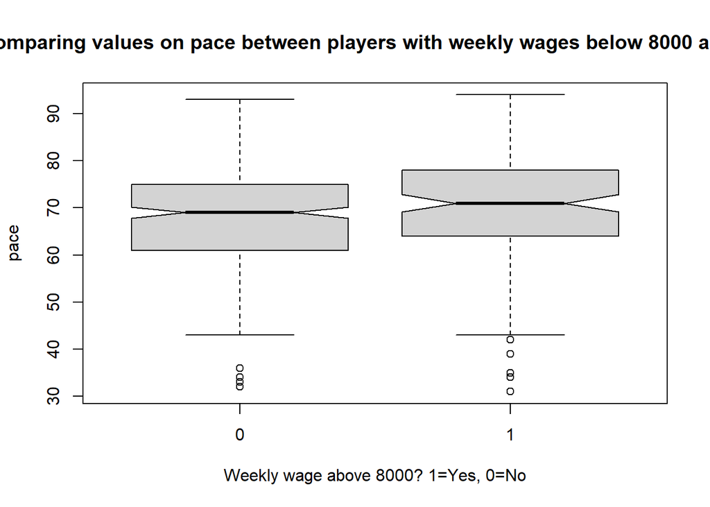

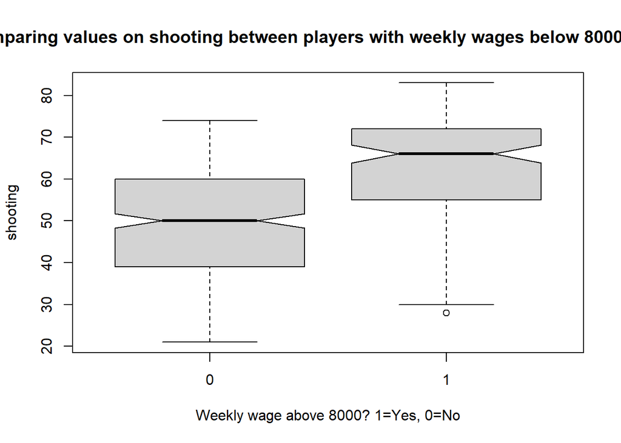

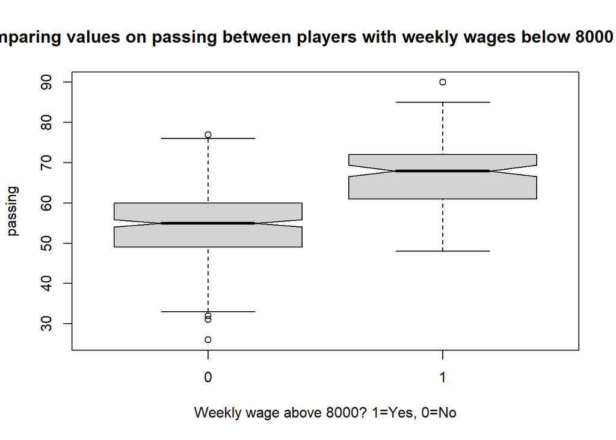

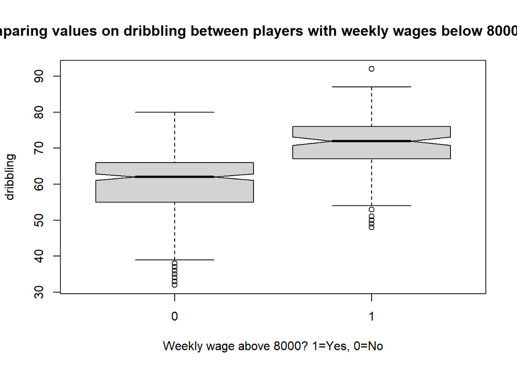

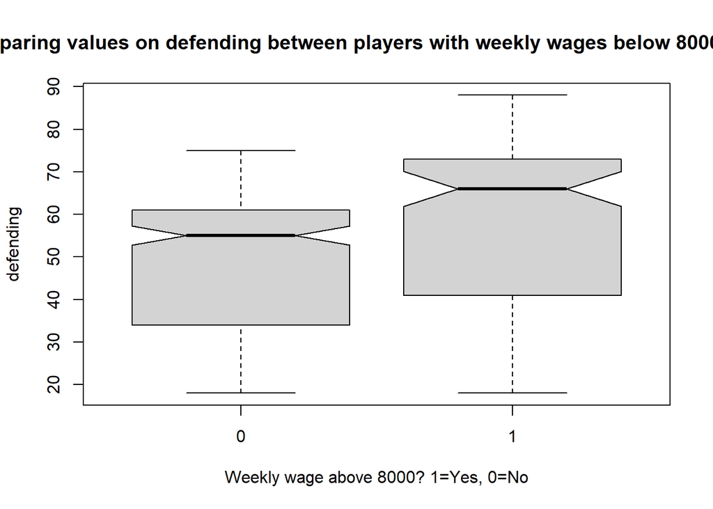

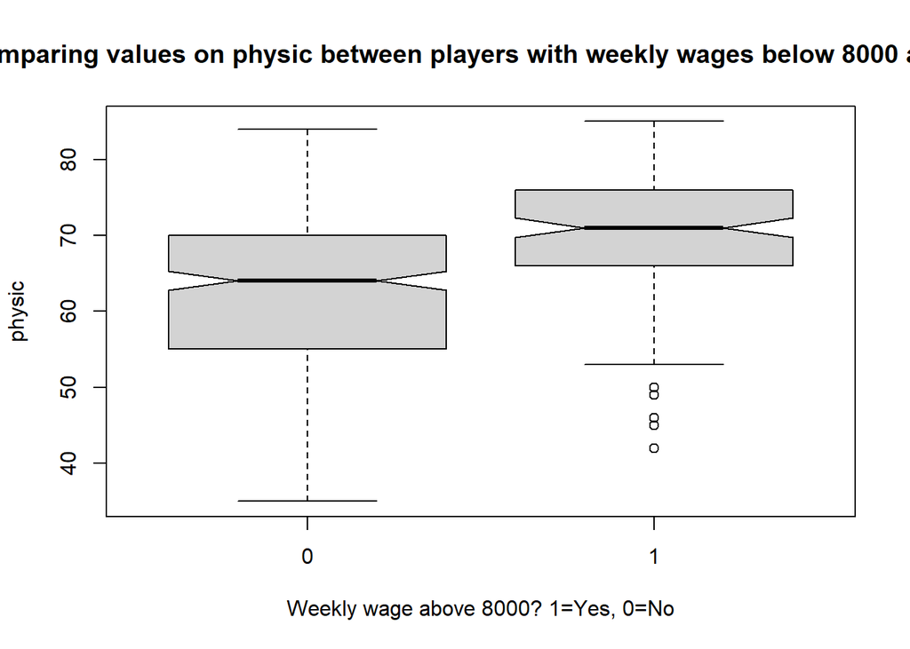

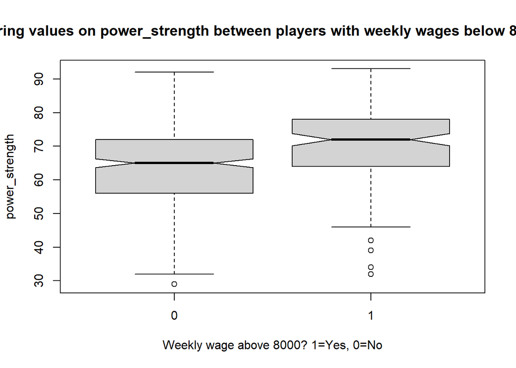

[1 more figures not shown]

```r
c_col <- c("wage_eur_log",
           "age",
           "height_cm",
           "weight_kg",
           "potential",
           "pace",
           "shooting",
           "passing",
           "dribbling",
           "defending",
           "physic",
           "power_strength",
           "power_long_shots")

for (col in c_col){
  title = paste("Boxplot comparing values on", col, "between players with weekly wages below 8000 and above 8000")
  x_axis = "Weekly wage above 8000? 1=Yes, 0=No"
  y_axis = col
  boxplot(df[,col]~df[,"high.wage.ind"],
          data=df,
          notch=TRUE,
          main=title,
          xlab=x_axis,
          ylab=y_axis)
}
```

- Boxplots show that there is statistical significance in the difference of medians between `high.wage.ind` and the following columns: `wage_eur_log` (more than obvious since `high.wage.ind` is calculated from `wage_eur`), `age` (small), `height_cm` (barely), `potential`, `shooting`, `passing`, `dribbling`, `defending`, `physic`, `power_strength` and `power_long_shots`. Boxplots show that there is no statistical significance in the difference in medians between `high.wage.ind` and the following columns: `weight_kg` and `pace`.

Performing two sided t-test to find if there is significance difference in means between `high.wage.ind` and the other numerical columns.

```r
for (col in c_col){
  message <- paste("Results for column", col)
  print(message)
  ttest_result <- t.test(df[,col]~df[,"high.wage.ind"], alternative="two.sided")
  print(ttest_result[5])
  print(ttest_result[3])
  if (ttest_result[3]<0.05){
    message_1 <- "P-value is very small, we reject null-hypothesis and we say there is statistical significance in the difference of means."
    print(message_1)
  }
  else {
    message_2 <- "P-value is big. We failed to reject the null-hypotheis. There is no evidence that there is statistical significance in the diffence of means."
    print(message_2)
  }
  cat("----------------------------------------------------------------------------------------------------------------\n\n\n")
}
```

```
## [1] "Results for column wage_eur_log"
## $estimate
## mean in group 0 mean in group 1
##        7.479091       10.031782
##
## $p.value
## [1] 0.000000000000000000000000000000000000000000000000000000000000000000000000000000000000000000000000000000000000002154836
##
## [1] "P-value is very small, we reject null-hypothesis and we say there is statistical significance in the difference of means."
## ----------------------------------------------------------------------------------------------------------------
##
##
## [1] "Results for column age"
## $estimate
## mean in group 0 mean in group 1
##        24.53151        26.65772
##
## $p.value
## [1] 0.0000003435215
##
## [1] "P-value is very small, we reject null-hypothesis and we say there is statistical significance in the difference of means."
## ----------------------------------------------------------------------------------------------------------------
##
##
## [1] "Results for column height_cm"
## $estimate
## mean in group 0 mean in group 1
##        179.4644        181.3221
##
## $p.value
## [1] 0.004946459
##
## [1] "P-value is very small, we reject null-hypothesis and we say there is statistical significance in the difference of means."
## ----------------------------------------------------------------------------------------------------------------
##
##
## [1] "Results for column weight_kg"
## $estimate
## mean in group 0 mean in group 1
##        73.72099        75.84564
```

[output cut: 99 more lines]

```
##
## [1] "P-value is very small, we reject null-hypothesis and we say there is statistical significance in the difference of means."
## ----------------------------------------------------------------------------------------------------------------
##
##
## [1] "Results for column power_long_shots"
## $estimate
## mean in group 0 mean in group 1
##        47.45753        62.54362
##
## $p.value
## [1] 0.00000000000000000000002527995
##
## [1] "P-value is very small, we reject null-hypothesis and we say there is statistical significance in the difference of means."
## ----------------------------------------------------------------------------------------------------------------
```

Columns `wage_eur_log`, `age`, `height_cm`, `weight_cm`, `potential`, `shooting`, `passing`, `dribbling`, `defending`, `physic`, `power_strength` and `power_long_shots` have shown to have statistical significance in their difference of means between players that have weekly payments less than 8000 and above 8000. Column `pace` has shows to not have statistical significance in the difference of means.

Looking for a relationship between `preferred_foot` and `high.wage.ind`:

```r
table_wage_foot <- table(df$high.wage.ind, df$preferred_foot)
table_wage_foot
```

```
##
##     Left Right
##   0   85   280
##   1   36   113
```

```r
chisq.test(table_wage_foot)
```

```
##
##  Pearson's Chi-squared test with Yates' continuity correction
##
## data:  table_wage_foot
## X-squared = 0.0094454, df = 1, p-value = 0.9226
```

P-value is 0.9226, therefore failed to reject the null hypothesis and we say there is no relationship between `preferred_foot` and `high.wage.ind`.

## 2.3 Additional insights and issues

*Highlight potential further issues or insights uncovered in 2.2. This might include follow up to findings from your initial EDA. We accept that the boundary between 2.2 and 2.3 is somewhat arbitrary so use your judgement and maximize good structure and readability. (5 marks)*

No further issues where found during the EDA, all issues were found and fixed during the data cleaning.

# 3. Modelling

## 3.1 Build a model for player potential

*Given the research question (i.e., player potential) outline an analysis plan that incorporates/references any findings from the data cleaning (1.3) and EDA (2.2) (5 marks). Use R to build a suitable model (10 marks).*  
*NB Submissions where suitable models do not have good fit due to the nature of the data will not be penalized.*

- From the EDA process, I have found that column `wage_eur` follows a logarithmic distribution. Therefore, a logarithmic transformation was applied to make the column more suitable for usage in the model. The transformation was stored in the `wage_eur_log` column. [6]
- From the EDA process, I have found that columns `power_long_shots`, `power_strength`, `physic`, `defending`, `dribbling`, `shooting`, `pace`, `weight_kg`, `wage_eur_log`, `age`, `potential` do not follow a normal distribution. Only columns `height_cm`, and `passing` follow a normal distribution. Therefore, when trying to find correlation between the columns, the Spearman method was used.
- In order to avoid collinearity, features that are highly correlated (>=0.8) between each other, will not be used. `height_cm` and `weight_kg` are highly correlated, for this case `height_cm` will be used because it follows a normal distribution. `dribbling` is highly correlated with `shooting` and `passing`, for this case we will use `dibbling` and remove `shooting` and `passing` in the model. In this way, we use one feature instead of two and make the model simplier, and also because dribbling has more correlation with `potential` than the other 2 features. `physic` and `power_strength` are also highly correlated, I will use `physic` and not use `power_strength` because `physic` has a higher correlation with `potential` than `power_strength` with `potential`. In summary, columns `weight_kg`, `shooting`, `passing`, `power_strenght` will not be used in the model.
- Using ANOVA and boxplots with notches, we have found that there is not statistical significance in median and mean of player’s potential between players who preferred right foot and left foot. Therefore, the column `preferred_foot` will not be used in the model. On the other hand, it was found that there was a statistical signficance in median and mean of player’s potential between players whose weekly wages are above 8000 euros and those below 8000 euros. However, the column `high.wage.ind` is taken from the `wage_eur` column which does not bring extra information, it only confirms that `wage_eur_log` is a good feature for our model. If `high.wage.ind` is used, an interaction problem with `wage_eur_log` will surged.
- `age` and `defending` may have a quadratic relationships on potential as seen as on the linear regressions performed on the EDA.
- First I will build a complex model and take note of the significant coefficients. Then I will build a very simple model and start adding significant coefficients found in the complex model.

**model0**

```r
mr_model0 <- lm(potential ~ wage_eur_log*age*height_cm*pace*dribbling*defending*physic*power_long_shots +
                            I(wage_eur_log^2)+
                            I(age^2) +
                            I(height_cm^2) +
                            I(pace^2) +
                            I(dribbling^2) +
                            I(defending^2) +
                            I(physic^2) +
                            I(power_long_shots^2), data=df)
summary(mr_model0)
```

```
##
## Call:
## lm(formula = potential ~ wage_eur_log * age * height_cm * pace *
##     dribbling * defending * physic * power_long_shots + I(wage_eur_log^2) +
##     I(age^2) + I(height_cm^2) + I(pace^2) + I(dribbling^2) +
##     I(defending^2) + I(physic^2) + I(power_long_shots^2), data = df)
##
## Residuals:
##     Min      1Q  Median      3Q     Max
## -6.8602 -0.9462 -0.0291  0.9572  6.1651
##
## Coefficients: (1 not defined because of singularities)
##                                                                                        Estimate
## (Intercept)                                                                 427405.034363127954
## wage_eur_log                                                                -40301.401010620160
## age                                                                          32839.128403441748
## height_cm                                                                    -2067.053106715392
## pace                                                                          2233.809102541663
## dribbling                                                                   -14884.233093490198
## defending                                                                    -7296.221614994129
## physic                                                                       -8818.663226317689
## power_long_shots                                                            -25832.658239883862
## I(wage_eur_log^2)                                                                0.690066755844
## I(age^2)                                                                         0.074923577237
## I(height_cm^2)                                                                   0.000072019611
## I(pace^2)                                                                        0.002342111916
## I(dribbling^2)                                                                   0.009574794368
## I(defending^2)                                                                   0.005052403570
## I(physic^2)                                                                      0.002876070656
## I(power_long_shots^2)                                                            0.000385620411
## wage_eur_log:age                                                             -4643.973125183560
## wage_eur_log:height_cm                                                         164.469514853294
## age:height_cm                                                                 -190.875866432536
## wage_eur_log:pace                                                             -251.577958288820
## age:pace                                                                      -773.111244189751
## height_cm:pace                                                                 -18.408316336233
## wage_eur_log:dribbling                                                        1837.433287764628
## age:dribbling                                                                 -192.306002859222
## height_cm:dribbling                                                             78.751112293509
## pace:dribbling                                                                  68.925695086549
```

[output cut: 1288 more lines]

```
## wage_eur_log:age:height_cm:pace:dribbling:defending:physic
## wage_eur_log:age:height_cm:pace:dribbling:defending:power_long_shots
## wage_eur_log:age:height_cm:pace:dribbling:physic:power_long_shots
## wage_eur_log:age:height_cm:pace:defending:physic:power_long_shots           .
## wage_eur_log:age:height_cm:dribbling:defending:physic:power_long_shots
## wage_eur_log:age:pace:dribbling:defending:physic:power_long_shots
## wage_eur_log:height_cm:pace:dribbling:defending:physic:power_long_shots     **
## age:height_cm:pace:dribbling:defending:physic:power_long_shots
## wage_eur_log:age:height_cm:pace:dribbling:defending:physic:power_long_shots
## ---
## Signif. codes:  0 '***' 0.001 '**' 0.01 '*' 0.05 '.' 0.1 ' ' 1
##
## Residual standard error: 2.196 on 251 degrees of freedom
## Multiple R-squared:  0.9422, Adjusted R-squared:  0.8818
## F-statistic: 15.61 on 262 and 251 DF,  p-value: < 0.00000000000000022
```

Coefficients `I(wage_eur_log^2)`, `I(age^2)`, `I(defending^2)`, `dribbling:power_long_shots` are significant here. There are other significant coefficients as well but they will not be used because it makes the model too complex (e.g. `wage_eur_log:dribbling:power_long_shots`)

**model1**

Starting with a very simple model:

```r
mr_model1 <- lm(potential ~ wage_eur_log +
                            age +
                            height_cm +
                            pace +
                            dribbling +
                            defending +
                            physic +
                            power_long_shots, data=df)
summary(mr_model1)
```

```
##
## Call:
## lm(formula = potential ~ wage_eur_log + age + height_cm + pace +
##     dribbling + defending + physic + power_long_shots, data = df)
##
## Residuals:
##      Min       1Q   Median       3Q      Max
## -11.5916  -2.4986  -0.3558   2.2130  12.2437
##
## Coefficients:
##                  Estimate Std. Error t value             Pr(>|t|)
## (Intercept)      37.51410    6.01978   6.232       0.000000000973 ***
## wage_eur_log      1.53614    0.15548   9.880 < 0.0000000000000002 ***
## age              -0.85509    0.04340 -19.704 < 0.0000000000000002 ***
## height_cm         0.07956    0.03186   2.497               0.0128 *
## pace             -0.03197    0.01965  -1.627               0.1045
## dribbling         0.31234    0.03173   9.844 < 0.0000000000000002 ***
## defending         0.07029    0.01333   5.274       0.000000197843 ***
## physic            0.10910    0.02611   4.179       0.000034561395 ***
## power_long_shots  0.01020    0.01707   0.598               0.5503
## ---
## Signif. codes:  0 '***' 0.001 '**' 0.01 '*' 0.05 '.' 0.1 ' ' 1
##
## Residual standard error: 3.677 on 505 degrees of freedom
## Multiple R-squared:  0.6741, Adjusted R-squared:  0.6689
## F-statistic: 130.6 on 8 and 505 DF,  p-value: < 0.00000000000000022
```

**model2**

`power_long_shots` has the least significant coefficient. It will be removed.

```r
mr_model2 <- update(mr_model1,~.-power_long_shots)
summary(mr_model2)
```

```
##
## Call:
## lm(formula = potential ~ wage_eur_log + age + height_cm + pace +
##     dribbling + defending + physic, data = df)
##
## Residuals:
##      Min       1Q   Median       3Q      Max
## -11.6786  -2.4719  -0.3568   2.2162  12.4024
##
## Coefficients:
##              Estimate Std. Error t value             Pr(>|t|)
## (Intercept)  37.44423    6.01482   6.225        0.00000000101 ***
## wage_eur_log  1.54437    0.15477   9.979 < 0.0000000000000002 ***
## age          -0.85094    0.04281 -19.876 < 0.0000000000000002 ***
## height_cm     0.07883    0.03182   2.477               0.0136 *
## pace         -0.03466    0.01912  -1.812               0.0705 .
## dribbling     0.32428    0.02465  13.158 < 0.0000000000000002 ***
## defending     0.06771    0.01260   5.375        0.00000011729 ***
## physic        0.11099    0.02590   4.285        0.00002186890 ***
## ---
## Signif. codes:  0 '***' 0.001 '**' 0.01 '*' 0.05 '.' 0.1 ' ' 1
##
## Residual standard error: 3.674 on 506 degrees of freedom
## Multiple R-squared:  0.6739, Adjusted R-squared:  0.6694
## F-statistic: 149.4 on 7 and 506 DF,  p-value: < 0.00000000000000022
```

**model3**

`pace` has the least significant coefficient. It will be removed.

```r
mr_model3 <- update(mr_model2,~.-pace)
summary(mr_model3)
```

```
##
## Call:
## lm(formula = potential ~ wage_eur_log + age + height_cm + dribbling +
##     defending + physic, data = df)
##
## Residuals:
##      Min       1Q   Median       3Q      Max
## -11.4664  -2.5034  -0.2909   2.2721  12.3385
##
## Coefficients:
##              Estimate Std. Error t value             Pr(>|t|)
## (Intercept)  33.00158    5.50507   5.995        0.00000000387 ***
## wage_eur_log  1.56838    0.15455  10.148 < 0.0000000000000002 ***
## age          -0.83232    0.04165 -19.982 < 0.0000000000000002 ***
## height_cm     0.09518    0.03058   3.112              0.00196 **
## dribbling     0.30461    0.02218  13.736 < 0.0000000000000002 ***
## defending     0.07092    0.01250   5.674        0.00000002347 ***
## physic        0.10384    0.02566   4.047        0.00005990173 ***
## ---
## Signif. codes:  0 '***' 0.001 '**' 0.01 '*' 0.05 '.' 0.1 ' ' 1
##
## Residual standard error: 3.683 on 507 degrees of freedom
## Multiple R-squared:  0.6718, Adjusted R-squared:  0.6679
## F-statistic: 172.9 on 6 and 507 DF,  p-value: < 0.00000000000000022
```

**model4**

`I(wage_eur_log^2)` will be added since it has been shown in the complex model that it posses a significant coefficient.

```r
mr_model4 <- update(mr_model3,~.+I(wage_eur_log^2))
summary(mr_model4)
```

```
##
## Call:
## lm(formula = potential ~ wage_eur_log + age + height_cm + dribbling +
##     defending + physic + I(wage_eur_log^2), data = df)
##
## Residuals:
##      Min       1Q   Median       3Q      Max
## -10.9439  -2.4533  -0.1034   2.2268  11.9656
##
## Coefficients:
##                   Estimate Std. Error t value             Pr(>|t|)
## (Intercept)       72.71138    7.52941   9.657 < 0.0000000000000002 ***
## wage_eur_log      -7.11112    1.19123  -5.970    0.000000004480176 ***
## age               -0.81786    0.03969 -20.608 < 0.0000000000000002 ***
## height_cm          0.07950    0.02918   2.724              0.00667 **
## dribbling          0.27281    0.02154  12.664 < 0.0000000000000002 ***
## defending          0.05894    0.01201   4.909    0.000001235064317 ***
## physic             0.11235    0.02444   4.596    0.000005433483767 ***
## I(wage_eur_log^2)  0.51938    0.07074   7.342    0.000000000000844 ***
## ---
## Signif. codes:  0 '***' 0.001 '**' 0.01 '*' 0.05 '.' 0.1 ' ' 1
##
## Residual standard error: 3.504 on 506 degrees of freedom
## Multiple R-squared:  0.7034, Adjusted R-squared:  0.6993
## F-statistic: 171.4 on 7 and 506 DF,  p-value: < 0.00000000000000022
```

**model5**

`I(age^2)` will be added since it has been shown in the complex model that it posses a significant coefficient.

```r
mr_model5 <- update(mr_model4,~.+I(age^2))
summary(mr_model5)
```

```
##
## Call:
## lm(formula = potential ~ wage_eur_log + age + height_cm + dribbling +
##     defending + physic + I(wage_eur_log^2) + I(age^2), data = df)
##
## Residuals:
##      Min       1Q   Median       3Q      Max
## -10.5296  -2.0687  -0.1365   1.9882  11.5235
##
## Coefficients:
##                    Estimate Std. Error t value             Pr(>|t|)
## (Intercept)       112.32393    7.21462  15.569 < 0.0000000000000002 ***
## wage_eur_log       -4.66319    1.05065  -4.438   0.0000111381845827 ***
## age                -4.96452    0.32246 -15.396 < 0.0000000000000002 ***
## height_cm           0.06487    0.02534   2.560               0.0108 *
## dribbling           0.30173    0.01882  16.030 < 0.0000000000000002 ***
## defending           0.06045    0.01042   5.804   0.0000000114695501 ***
## physic              0.17157    0.02169   7.908   0.0000000000000165 ***
## I(wage_eur_log^2)   0.37698    0.06235   6.046   0.0000000028856705 ***
## I(age^2)            0.07864    0.00608  12.934 < 0.0000000000000002 ***
## ---
## Signif. codes:  0 '***' 0.001 '**' 0.01 '*' 0.05 '.' 0.1 ' ' 1
##
## Residual standard error: 3.04 on 505 degrees of freedom
## Multiple R-squared:  0.7772, Adjusted R-squared:  0.7736
## F-statistic: 220.2 on 8 and 505 DF,  p-value: < 0.00000000000000022
```

**model6**

`I(defending^2)` will be added since it has been shown in the complex model that it posses a significant coefficient.

```r
mr_model6 <- update(mr_model5,~.+I(defending^2))
summary(mr_model6)
```

```
##
## Call:
## lm(formula = potential ~ wage_eur_log + age + height_cm + dribbling +
##     defending + physic + I(wage_eur_log^2) + I(age^2) + I(defending^2),
##     data = df)
##
## Residuals:
##      Min       1Q   Median       3Q      Max
## -10.0805  -2.0434  -0.1617   2.0537  10.3276
##
## Coefficients:
##                      Estimate  Std. Error t value             Pr(>|t|)
## (Intercept)       114.1618122   7.0543648  16.183 < 0.0000000000000002 ***
## wage_eur_log       -3.6916435   1.0437626  -3.537             0.000442 ***
## age                -4.9081759   0.3150715 -15.578 < 0.0000000000000002 ***
## height_cm           0.0636173   0.0247475   2.571             0.010436 *
## dribbling           0.3124827   0.0185030  16.888 < 0.0000000000000002 ***
## defending          -0.2199382   0.0563329  -3.904             0.000107 ***
## physic              0.1647190   0.0212273   7.760   0.0000000000000476 ***
## I(wage_eur_log^2)   0.3073120   0.0624208   4.923   0.0000011554437612 ***
## I(age^2)            0.0776776   0.0059405  13.076 < 0.0000000000000002 ***
## I(defending^2)      0.0029532   0.0005836   5.061   0.0000005867605736 ***
## ---
## Signif. codes:  0 '***' 0.001 '**' 0.01 '*' 0.05 '.' 0.1 ' ' 1
##
## Residual standard error: 2.969 on 504 degrees of freedom
## Multiple R-squared:  0.7879, Adjusted R-squared:  0.7842
## F-statistic: 208.1 on 9 and 504 DF,  p-value: < 0.00000000000000022
```

**model7**

`dribbling:power_long_shots` will be added since it has been shown in the complex model that it posses a significant coefficient.

```r
mr_model7 <- update(mr_model6,~. + dribbling:power_long_shots)
summary(mr_model7)
```

```
##
## Call:
## lm(formula = potential ~ wage_eur_log + age + height_cm + dribbling +
##     defending + physic + I(wage_eur_log^2) + I(age^2) + I(defending^2) +
##     dribbling:power_long_shots, data = df)
##
## Residuals:
##     Min      1Q  Median      3Q     Max
## -9.9620 -2.0128 -0.1722  1.9967 10.1432
##
## Coefficients:
##                               Estimate  Std. Error t value             Pr(>|t|)
## (Intercept)                114.9109253   7.0808954  16.228 < 0.0000000000000002
## wage_eur_log                -3.6360710   1.0444681  -3.481             0.000542
## age                         -4.8902573   0.3153306 -15.508 < 0.0000000000000002
## height_cm                    0.0630427   0.0247434   2.548             0.011135
## dribbling                    0.2868151   0.0287175   9.987 < 0.0000000000000002
## defending                   -0.2210063   0.0563199  -3.924    0.000099154674066
## physic                       0.1623905   0.0213129   7.619    0.000000000000128
## I(wage_eur_log^2)            0.3021367   0.0625552   4.830    0.000001815737424
## I(age^2)                     0.0771825   0.0059534  12.964 < 0.0000000000000002
## I(defending^2)               0.0030008   0.0005848   5.132    0.000000411107175
## dribbling:power_long_shots   0.0002408   0.0002061   1.168             0.243190
##
## (Intercept)                ***
## wage_eur_log               ***
## age                        ***
## height_cm                  *
## dribbling                  ***
## defending                  ***
## physic                     ***
## I(wage_eur_log^2)          ***
## I(age^2)                   ***
## I(defending^2)             ***
## dribbling:power_long_shots
## ---
## Signif. codes:  0 '***' 0.001 '**' 0.01 '*' 0.05 '.' 0.1 ' ' 1
##
## Residual standard error: 2.968 on 503 degrees of freedom
## Multiple R-squared:  0.7885, Adjusted R-squared:  0.7843
## F-statistic: 187.5 on 10 and 503 DF,  p-value: < 0.00000000000000022
```

Model 7 shows that `dribbling:power_long_shots` is not significant so we will keep **model6** as our final model.

Analyzing model6:

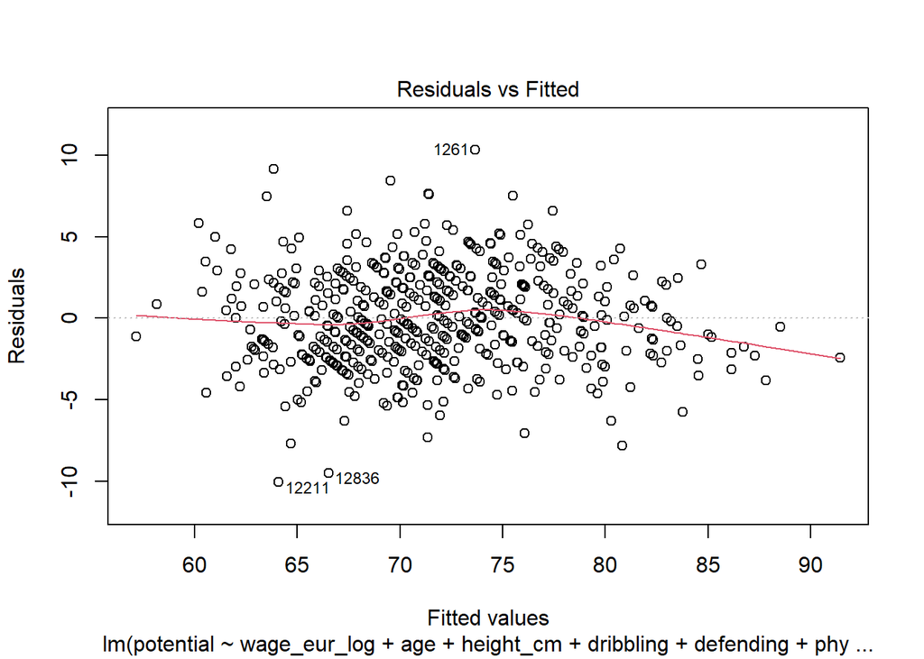

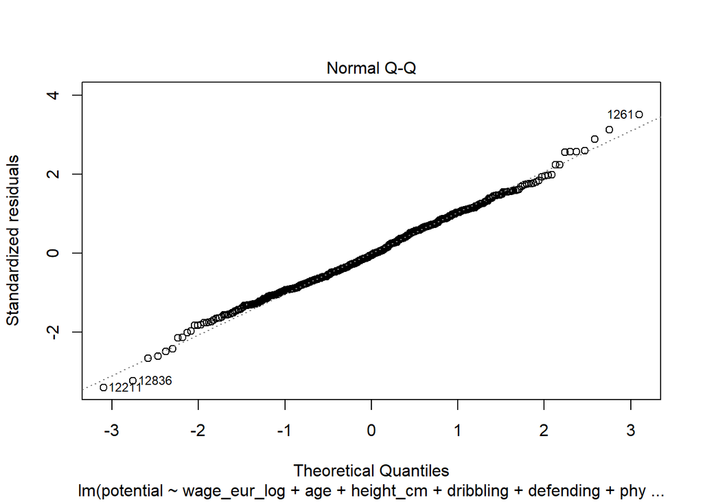

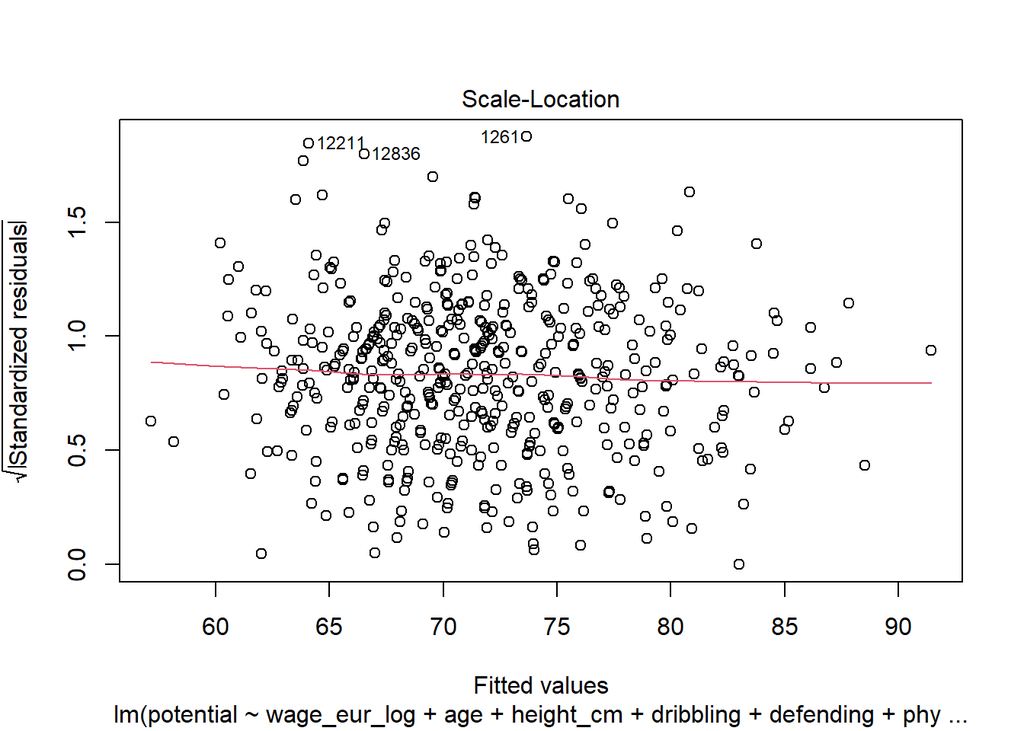

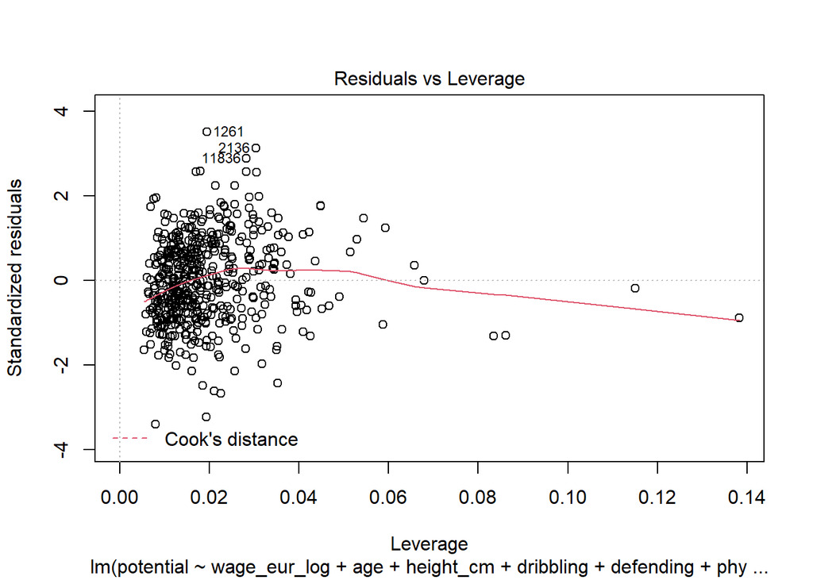

```r
plot(mr_model6)
```

In the graph “Residuals vs Fitted”, residuals are randomly distributed which means that there are not signs of heteroscedasticity. The Normal Q-Q plot shows that the standardized residuals do follow a normal distribution which means our model is good.

## 3.2 Critique model using relevant diagnostics

*Offer an interpretation of the model characteristics, goodness of fit and graphical diagnostics (5 marks) for the model built in 3.1. Explain any potential weaknesses (5 marks).*

$$potential=114.1618122 - 3.6916435 \times log(wage\_eur) - 4.9081759 \times age + 0.0636173 \times height\_cm + 0.3124827 \times dribbling - 0.2199382 \times defending + 0.1647190 \times physic + 0.3073120 \times log(wage\_eur)^2 + 0.0776776 \times age^2 + 0.0029532 \times defending^2$$

- The multi-regression coefficients gives you the size of effect that the feature is having on potential and the sign gives you whether that effect is positive or negative (e.g., for every unit increase in age there is 4.9 decrease in potential).

## 3.3 Suggest improvements to your model

*Based on the findings in 3.2 articulates possible alternative approaches to address them (5 marks).*

Since Multiple Regression is an algorithm that uses distance between points for the loss function, variables which range are higher (e.g., `wage_eur_log` range is significantly smaller than the range in `height_cm`) will have a bigger impact in the model without being necessary more important than the other variables. A good way to fix this is to standardize numerical columns. In that way, your columns will follow a normal distribution and have a mean of 0 and a standard deviation of 1. In other words, they will have similar scale and will help the algorithm remove that bias.

# 4. Extension work

## 4.1 Model the likelihood of a player having a weekly wage above 8000 Euro (using the high.wage.ind variable provided).

*Given this second research question (i.e., involving the binary target attribute) provide a plan of analysis based on relevant EDA for this attribute (10 marks). The model is described, explained and critiqued (10 marks).* *NB Submissions where suitable models do not have good fit due to the nature of the data will not be penalized.*

Plan:

- Column `wage_eur_log` will not be used in the model because `high.wage.ind` is calculated from `wage_eur`. Therefore, when building the model, `wage_eur_log` will perfectly separate 1 and 0s and will lead the model to not converge. [7]
- From the EDA process, I have found that columns `power_long_shots`, `power_strength`, `physic`, `defending`, `dribbling`, `shooting`, `pace`, `weight_kg`, `wage_eur_log`, `age`, `potential` do not follow a normal distribution. Only columns `height_cm`, and `passing` follow a normal distribution.
- In order to avoid collinearity, features that are highly correlated (>=0.8) between each other, will not be used. `height_cm` and `weight_kg` are highly correlated, for this case `height_cm` will be used because it follows a normal distribution. `dribbling` is highly correlated with `shooting` and `passing`, for this case we will use `dibbling` and remove `shooting` and `passing` in the model. In this way, we use one feature instead of two and make the model simplier, and also because dribbling has more correlation with `potential` than the other 2 features. `physic` and `power_strength` are also highly correlated, I will use `physic` and not use `power_strength` because `physic` has a higher correlation with `potential` than `power_strength` with `potential`. In summary, columns `weight_kg`, `shooting`, `passing`, `power_strenght` will not be used in the model.
- `Pace` has been shown to not have statistical significance in the difference in means between `high.wage_ind` = 0 and `high.wage_ind` = 1. I will not use this column in the model.
- `weight_kg` and `pace` have been shown to not have statistical significance in the difference in medians between `high.wage_ind` = 0 and `high.wage_ind` = 1. We don’t need to worry since we already said `weight_kg` will not be used to avoid collinearity and we already say we need to be careful with the `pace` column.
- First I will build a complex model and take note of the significant coefficients. Then I will build a very simple model and start adding significant coefficients found in the complex model.

**model0**

```r
lg_model0 <- glm(high.wage.ind ~ age*height_cm*dribbling*defending*physic*power_long_shots +
                                 I(age^2) +
                                 I(height_cm^2) +
                                 I(dribbling^2) +
                                 I(defending^2) +
                                 I(physic^2) +
                                 I(power_long_shots^2) +
                                 I(potential^2), data=df, family=binomial)
summary(lg_model0)
```

```
##
## Call:
## glm(formula = high.wage.ind ~ age * height_cm * dribbling * defending *
##     physic * power_long_shots + I(age^2) + I(height_cm^2) + I(dribbling^2) +
##     I(defending^2) + I(physic^2) + I(power_long_shots^2) + I(potential^2),
##     family = binomial, data = df)
##
## Deviance Residuals:
##     Min       1Q   Median       3Q      Max
## -3.5438  -0.1276  -0.0095   0.0266   2.5214
##
## Coefficients:
##                                                                    Estimate
## (Intercept)                                               -104802.945687643
## age                                                          5065.505866037
## height_cm                                                     550.708445183
## dribbling                                                    1652.854974104
## defending                                                     935.947507931
## physic                                                       1878.641544470
## power_long_shots                                             1576.187413386
## I(age^2)                                                       -0.063979068
## I(height_cm^2)                                                  0.002322525
## I(dribbling^2)                                                  0.008882192
## I(defending^2)                                                  0.003725136
## I(physic^2)                                                     0.002383801
## I(power_long_shots^2)                                          -0.000452889
## I(potential^2)                                                  0.004064609
## age:height_cm                                                 -26.867367385
## age:dribbling                                                 -78.921868822
## height_cm:dribbling                                            -8.707971840
## age:defending                                                 -57.902904586
## height_cm:defending                                            -4.852886988
## dribbling:defending                                           -15.785583857
## age:physic                                                    -84.474018943
## height_cm:physic                                               -9.858653918
## dribbling:physic                                              -29.025406883
## defending:physic                                              -18.762725039
## age:power_long_shots                                          -79.464142280
## height_cm:power_long_shots                                     -8.275082835
## dribbling:power_long_shots                                    -25.329073554
```

[output cut: 255 more lines]

```
## age:height_cm:dribbling:physic:power_long_shots
## age:height_cm:defending:physic:power_long_shots
## age:dribbling:defending:physic:power_long_shots
## height_cm:dribbling:defending:physic:power_long_shots
## age:height_cm:dribbling:defending:physic:power_long_shots
## ---
## Signif. codes:  0 '***' 0.001 '**' 0.01 '*' 0.05 '.' 0.1 ' ' 1
##
## (Dispersion parameter for binomial family taken to be 1)
##
##     Null deviance: 618.90  on 513  degrees of freedom
## Residual deviance: 174.95  on 443  degrees of freedom
## AIC: 316.95
##
## Number of Fisher Scoring iterations: 11
```

Columns `I(age^2)`, `I(defending^2)`, `I(potential^2)` were found to be significant.

**model1**

Simple model is built.

```r
lg_model1 <- glm(high.wage.ind ~ age +
                                 height_cm +
                                 dribbling +
                                 defending +
                                 physic +
                                 power_long_shots +
                                 potential, data=df, family=binomial)
summary(lg_model1)
```

```
##
## Call:
## glm(formula = high.wage.ind ~ age + height_cm + dribbling + defending +
##     physic + power_long_shots + potential, family = binomial,
##     data = df)
##
## Deviance Residuals:
##     Min       1Q   Median       3Q      Max
## -2.5562  -0.3949  -0.1215   0.1460   2.5659
##
## Coefficients:
##                    Estimate Std. Error z value            Pr(>|z|)
## (Intercept)      -57.201931   7.230179  -7.912 0.00000000000000254 ***
## age                0.272083   0.054216   5.018 0.00000052078334155 ***
## height_cm          0.070703   0.029736   2.378            0.017422 *
## dribbling          0.112784   0.031888   3.537            0.000405 ***
## defending          0.029214   0.011970   2.441            0.014667 *
## physic            -0.003968   0.023945  -0.166            0.868375
## power_long_shots   0.026991   0.015248   1.770            0.076711 .
## potential          0.359693   0.048786   7.373 0.00000000000016692 ***
## ---
## Signif. codes:  0 '***' 0.001 '**' 0.01 '*' 0.05 '.' 0.1 ' ' 1
##
## (Dispersion parameter for binomial family taken to be 1)
##
##     Null deviance: 618.9  on 513  degrees of freedom
## Residual deviance: 278.6  on 506  degrees of freedom
## AIC: 294.6
##
## Number of Fisher Scoring iterations: 7
```

**model2**

Now I will add the significant coefficients found on model0 to model2 which are `I(age^2)`, `I(defending^2)`, and `I(potential^2)`.

```r
lg_model2 <- glm(high.wage.ind ~ age +
                                 height_cm +
                                 dribbling +
                                 defending +
                                 physic +
                                 power_long_shots +
                                 potential +
                                 I(age^2) +
                                 I(defending^2) +
                                 I(potential^2), data=df, family=binomial)
summary(lg_model2)
```

```
##
## Call:
## glm(formula = high.wage.ind ~ age + height_cm + dribbling + defending +
##     physic + power_long_shots + potential + I(age^2) + I(defending^2) +
##     I(potential^2), family = binomial, data = df)
##
## Deviance Residuals:
##      Min        1Q    Median        3Q       Max
## -2.71845  -0.30933  -0.06546   0.14135   2.45539
##
## Coefficients:
##                      Estimate   Std. Error z value  Pr(>|z|)
## (Intercept)      -144.2591414   41.5384562  -3.473  0.000515 ***
## age                 2.4575823    0.6037411   4.071 0.0000469 ***
## height_cm           0.0489837    0.0319654   1.532  0.125425
## dribbling           0.0755562    0.0385326   1.961  0.049898 *
## defending          -0.2104275    0.0854109  -2.464  0.013751 *
## physic             -0.0378334    0.0274971  -1.376  0.168852
## power_long_shots    0.0385787    0.0169750   2.273  0.023046 *
## potential           2.2036432    1.1110701   1.983  0.047328 *
## I(age^2)           -0.0399280    0.0108332  -3.686  0.000228 ***
## I(defending^2)      0.0024210    0.0008875   2.728  0.006373 **
## I(potential^2)     -0.0118716    0.0074457  -1.594  0.110839
## ---
## Signif. codes:  0 '***' 0.001 '**' 0.01 '*' 0.05 '.' 0.1 ' ' 1
##
## (Dispersion parameter for binomial family taken to be 1)
##
##     Null deviance: 618.90  on 513  degrees of freedom
## Residual deviance: 240.12  on 503  degrees of freedom
## AIC: 262.12
##
## Number of Fisher Scoring iterations: 7
```

**model3**

`physic` column is not a significant coefficient so it will be removed from model2.

```r
lg_model3 <- update(lg_model2,~.-physic)

summary(lg_model3)
```

```
##
## Call:
## glm(formula = high.wage.ind ~ age + height_cm + dribbling + defending +
##     power_long_shots + potential + I(age^2) + I(defending^2) +
##     I(potential^2), family = binomial, data = df)
##
## Deviance Residuals:
##      Min        1Q    Median        3Q       Max
## -2.80516  -0.32330  -0.06313   0.14219   2.45454
##
## Coefficients:
##                      Estimate   Std. Error z value  Pr(>|z|)
## (Intercept)      -142.9301065   40.8844611  -3.496  0.000472 ***
## age                 2.2328591    0.5733234   3.895 0.0000984 ***
## height_cm           0.0329031    0.0296654   1.109  0.267370
## dribbling           0.0860689    0.0379864   2.266  0.023465 *
## defending          -0.2188485    0.0845144  -2.589  0.009612 **
## power_long_shots    0.0352084    0.0166060   2.120  0.033987 *
## potential           2.2935743    1.0912843   2.102  0.035578 *
## I(age^2)           -0.0363405    0.0103747  -3.503  0.000460 ***
## I(defending^2)      0.0024432    0.0008817   2.771  0.005586 **
## I(potential^2)     -0.0126722    0.0073044  -1.735  0.082763 .
## ---
## Signif. codes:  0 '***' 0.001 '**' 0.01 '*' 0.05 '.' 0.1 ' ' 1
##
## (Dispersion parameter for binomial family taken to be 1)
##
##     Null deviance: 618.90  on 513  degrees of freedom
## Residual deviance: 242.06  on 504  degrees of freedom
## AIC: 262.06
##
## Number of Fisher Scoring iterations: 7
```

**model4**

`height_cm` column is not a significant coefficient so it will be removed from model3.

```r
lg_model4 <- update(lg_model3,~.-height_cm)

summary(lg_model4)
```

```
##
## Call:
## glm(formula = high.wage.ind ~ age + dribbling + defending + power_long_shots +
##     potential + I(age^2) + I(defending^2) + I(potential^2), family = binomial,
##     data = df)
##
## Deviance Residuals:
##     Min       1Q   Median       3Q      Max
## -2.8620  -0.3202  -0.0668   0.1361   2.5007
##
## Coefficients:
##                      Estimate   Std. Error z value  Pr(>|z|)
## (Intercept)      -138.8253817   40.4575875  -3.431  0.000601 ***
## age                 2.3847270    0.5613062   4.249 0.0000215 ***
## dribbling           0.0656418    0.0329937   1.990  0.046643 *
## defending          -0.2202835    0.0837244  -2.631  0.008512 **
## power_long_shots    0.0379794    0.0163750   2.319  0.020376 *
## potential           2.2971500    1.0862434   2.115  0.034450 *
## I(age^2)           -0.0389509    0.0101871  -3.824  0.000132 ***
## I(defending^2)      0.0024510    0.0008724   2.810  0.004961 **
## I(potential^2)     -0.0125484    0.0072689  -1.726  0.084290 .
## ---
## Signif. codes:  0 '***' 0.001 '**' 0.01 '*' 0.05 '.' 0.1 ' ' 1
##
## (Dispersion parameter for binomial family taken to be 1)
##
##     Null deviance: 618.9  on 513  degrees of freedom
## Residual deviance: 243.3  on 505  degrees of freedom
## AIC: 261.3
##
## Number of Fisher Scoring iterations: 7
```

**model5**

`I(potential^2)` has been shown to have low significance. Therefore it will be removed from model 4.

```r
lg_model5 <- update(lg_model4,~.-I(potential^2))

summary(lg_model5)
```

```
##
## Call:
## glm(formula = high.wage.ind ~ age + dribbling + defending + power_long_shots +
##     potential + I(age^2) + I(defending^2), family = binomial,
##     data = df)
##
## Deviance Residuals:
##      Min        1Q    Median        3Q       Max
## -2.86148  -0.32449  -0.08563   0.11175   2.45009
##
## Coefficients:
##                     Estimate  Std. Error z value           Pr(>|z|)
## (Intercept)      -73.0617277  10.3315670  -7.072 0.0000000000015305 ***
## age                2.6121957   0.5614537   4.653 0.0000032784273046 ***
## dribbling          0.0615119   0.0324929   1.893            0.05835 .
## defending         -0.2239394   0.0830827  -2.695            0.00703 **
## power_long_shots   0.0393219   0.0164313   2.393            0.01671 *
## potential          0.4380596   0.0567646   7.717 0.0000000000000119 ***
## I(age^2)          -0.0429493   0.0101425  -4.235 0.0000228961024058 ***
## I(defending^2)     0.0024820   0.0008672   2.862            0.00421 **
## ---
## Signif. codes:  0 '***' 0.001 '**' 0.01 '*' 0.05 '.' 0.1 ' ' 1
##
## (Dispersion parameter for binomial family taken to be 1)
##
##     Null deviance: 618.90  on 513  degrees of freedom
## Residual deviance: 246.36  on 506  degrees of freedom
## AIC: 262.36
##
## Number of Fisher Scoring iterations: 7
```

**Description, explanation and critique of the model:**

- First, I built a complex model with the features that were found important for `high.wage.ind` during the EDA with their quadratic relationship and interactions between them. `I(age^2)`, `I(defending^2)`, `I(potential^2)` were found to be significant. The AIC score of model0 is 316.95
- Second, I built a very simple model (model1). The column `physic` was no significant and column `power_long_shots` had very small significance. The AIC score decrease to 294.6 (lowest so far).
- Third, I added the significant coefficients found in model0 which were `I(age^2)`, `I(defending^2)`, and `I(potential^2)` to model1 to build model2. The AIC score decrease to 262.12 (lowest so far).
- Fourth, for model3, I removed column `physic` from model2 because it was not significant. The AIC score slightly decreased to 262.06 (lowest so far).
- Fifth, for model4, I removed column `height_cm` from model3 because it was not significant. The AIC score slightly decreased to 261.3 (lowest so far).
- Finally, for model5, I removed `I(potential^2)` from model4 because it had very low significance. However, the AIC score slightly increased to 262.36.
- Since model4 is the model which has the smallest AIC score, then this will be our model I will use.
- The model can be interpreted as follows:

$$log(\frac{p}{1-p})= -138.8253817 + 2.3847270 \times age + 0.0656418 \times dribbling - 0.2202835 \times defending + 0.0379794 \times power\_long\_shots + 2.2971500 \times potential - 0.0389509 \times age^2 + 0.0024510 \times defending^2 - 0.0125484 \times potential^2$$

# References

*Add any references here. NB You can either do this manually or automatically with a `.bib` file (which then must be submitted along with your `.Rmd` file). See the RMarkdown [documentation](https://bookdown.org/yihui/rmarkdown-cookbook/bibliography.html) for guidance.*

[1] J. Press, “The Japan News,” 13 August 2021. [Online]. Available: https://the-japan-news.com/news/article/0007672187. [Accessed 05 January 2022].

[2] FIFA, “FIFA,” 25 February 2021. [Online]. Available: https://www.fifa.com/news/kazuyoshi-miura-i-don-t-think-i-ll-ever-leave-football. [Accessed 06 January 2022].

[3] “Transfer Markt,” [Online]. Available: https://www.transfermarkt.com/kyle-hudlin/profil/spieler/829766. [Accessed 06 January 2022].

[4] “Colgadosporelfutbol.com,” [Online]. Available: https://colgadosporelfutbol.com/el-peso-ideal-de-un-futbolista-profesional-y-su-importancia/#:~:text=El%20margen%20estimado%20es%20de,por%20cada%202.5%20cent%C3%ADmetros%20adicionales. [Accessed 06 January 2022].

[5] S. Glen, “Statistics How to,” [Online]. Available: https://www.statisticshowto.com/logarithmic-distribution/. [Accessed 06 January 2022].

[6] K. S. Htoon, “Medium,” 29 February 2020. [Online]. Available: https://medium.com/@kyawsawhtoon/log-transformation-purpose-and-interpretation-9444b4b049c9. [Accessed 06 January 2022].

[7] “Statology,” 01 October 2021. [Online]. Available: https://www.statology.org/glm-fit-algorithm-did-not-converge/. [Accessed 06 January 2022].

[8] G. King y L. Zeng, «Logistic Regression in Rare,» Harvard University, Cambridge, MA, , 2001.